# Clustering_Credit_card

Divaynshu Goswami

February 28, 2019

```
                            Problem Statement
```

Data is of various customers of a bank with their credit limit , the total number of credit cards the customer has , and different channels through which customer has contacted the bank for any queries , different channels include visiting to bank , online and through call centre.

Marketing team plans to display offer ads on digital platform but only wants to target customers who are digitally more active , hence can we built different clusters of different channels so that based on different requirements the marketing team will target only customers falling under a particular cluster rather than targeting all the customers.

Note: This data is a completely dummy data and is created for this practical example only, it does not have any relevance to any organization.

```
                                Solution
```

We can provide a solution by clustering / segmenting customers and indentifying their profile.

```r
mydata<- read.csv('data_csv.csv')
```

Scale the data to make it unitless and calculate the distance matrix.

```r
#scale the data
mydata_scld <- scale(mydata[,3:7])
head(mydata_scld, 10)
```

```
##       Avg_Credit_Limit Total_Credit_Cards Total_visits_bank
##  [1,]       1.32739556         -1.1766968          1.449138
##  [2,]       0.06800698         -0.5883484         -0.621059
##  [3,]       0.06800698          1.7650452          1.449138
##  [4,]      -0.43574845          0.5883484          1.449138
##  [5,]       1.32739556          1.1766968         -0.621059
##  [6,]      -0.68762616         -0.5883484         -0.621059
##  [7,]       1.32739556          0.5883484         -0.621059
##  [8,]      -0.81356502         -0.5883484         -0.621059
##  [9,]      -1.06544274         -1.1766968         -0.621059
## [10,]      -1.11581828          0.0000000         -0.621059
##       Total_visits_online Total_calls_made
##  [1,]          -0.7033848       -1.3093073
##  [2,]           1.2149373        1.6366342
##  [3,]          -0.2770910        0.0000000
##  [4,]          -0.7033848        0.0000000
##  [5,]           1.6412311       -0.3273268
##  [6,]          -0.7033848        1.3093073
##  [7,]           1.4280842       -0.6546537
##  [8,]          -0.7033848       -0.9819805
##  [9,]          -0.4902379       -0.6546537
## [10,]          -0.7033848        0.9819805
```

```r
#Calculate distance matrix
mydata_dist <- dist(x=mydata_scld, method = "euclidean")
print(mydata_dist,digits = 3)
```

```
##        1     2     3     4     5     6     7     8     9
## 2  4.310
## 3  3.484 3.838
## 4  2.818 3.505 1.349
## 5  4.036 2.956 3.163 3.653
## 6  3.943 2.088 3.506 2.729 3.918
## 7  3.518 2.875 3.255 3.517 0.706 3.721
## 8  3.053 3.364 3.427 2.603 3.691 2.295 3.259
## 9  3.238 3.129 3.834 2.876 3.989 2.096 3.539 0.750
## 10 4.110 2.420 3.154 2.461 3.816 0.798 3.679 2.072 2.028
```

Form clusters by using a hierarchal technique and plot a dendogram to identify the appropriate number of clusters.

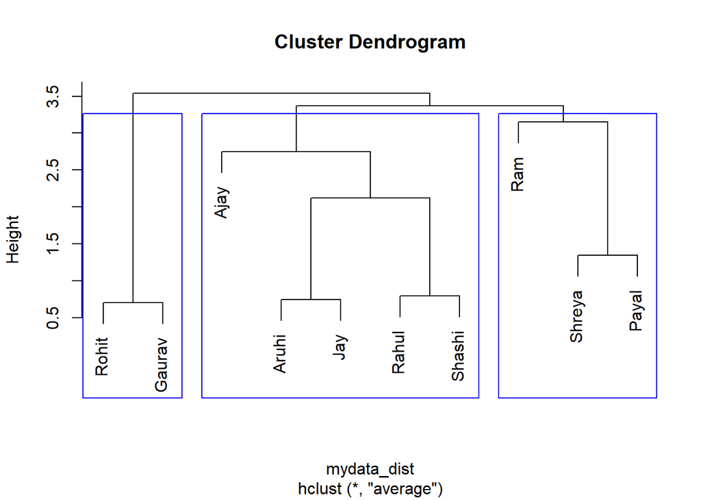

```r
require(graphics)
clust <- hclust(mydata_dist, method = "average")
plot(clust, labels =  as.character(mydata[,2]))
x <- rect.hclust(clust, k=3, border="blue")
```

Perform profiling of clusters on the main data

```r
mydata$cluster <- cutree(clust,k=3)
mydata_agg <- aggregate(mydata[,-c(1,2)], list(mydata$cluster), mean)
clust_profile <- data.frame(cluster=mydata_agg[,1], freq=as.vector(table(mydata$cluster)),mydata_agg[,-1])

print(clust_profile)
```

```
##   cluster freq Avg_Credit_Limit Total_Credit_Cards Total_visits_bank
## 1       1    3            60000           4.666667                 1
## 2       2    5            18600           3.000000                 0
## 3       3    2           100000           5.500000                 0
##   Total_visits_online Total_calls_made cluster.1
## 1            1.666667         2.666667         1
## 2            3.000000         5.400000         2
## 3           11.500000         2.500000         3
```

Hence, we can see that

Cluster 1 is of customers who make on an average 1 visit per month to the bank and have moderate credit limit of Rs. 60,000. Hence these customers can be targetted for ofline marketing of products.

Cluster 2 consists customers who have lowest credit limit but make around 5 to 6 calls in a month to ask queries. Hence marketing team should target these customers for phone banking services and products.

Cluster 3 is consist of customers who make most visits through online channels and also have highest average credit limit. Hence marketing team should target customers in cluster 3 for onlline marketing of products and offers.

Performing non hirarichal clustering K means

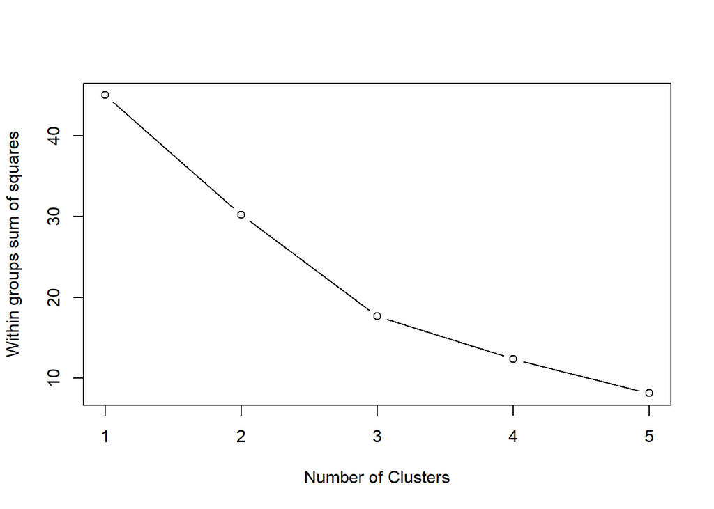

```r
#Create a wss function
wssplot <- function(data, nc=15, seed=1234){
  wss <- (nrow(data)-1)*sum(apply(data,2,var))
  for (i in 2:nc){
    set.seed(seed)
    wss[i] <- sum(kmeans(data, centers=i)$withinss)}
  plot(1:nc, wss, type="b", xlab="Number of Clusters",
       ylab="Within groups sum of squares")}

# use scaled data
wssplot(mydata_scld, nc=5)
```

We can see the elbow on the above graph to decide the number of clusters.

We will create 3 clusters using K-means clustering

```r
#nstart = 10 it will do the clustering process 25 times for each observation to check consistency of the obsevation on every iteration
clust_Km = kmeans(x=mydata_scld, centers = 3, nstart = 10)
clust_Km
```

```
## K-means clustering with 3 clusters of sizes 2, 3, 5
##
## Cluster means:
##   Avg_Credit_Limit Total_Credit_Cards Total_visits_bank
## 1        1.3273956          0.8825226         -0.621059
## 2        0.3198847          0.3922323          1.449138
## 3       -0.7228890         -0.5883484         -0.621059
##   Total_visits_online Total_calls_made
## 1           1.5346577       -0.4909903
## 2          -0.5612868       -0.4364358
## 3          -0.2770910        0.4582576
##
## Clustering vector:
##  [1] 2 3 2 2 1 3 1 3 3 3
##
## Within cluster sum of squares by cluster:
## [1]  0.2493642  7.2981254 10.1157855
##  (between_SS / total_SS =  60.7 %)
##
## Available components:
##
## [1] "cluster"      "centers"      "totss"        "withinss"
## [5] "tot.withinss" "betweenss"    "size"         "iter"
## [9] "ifault"
```

Let’s do the profiling of clusters

```r
## profiling the clusters
mydata$ClustersK <- clust_Km$cluster
mydata
```

```
##    Cust_ID   Name Avg_Credit_Limit Total_Credit_Cards Total_visits_bank
## 1        1    Ram           100000                  2                 1
## 2        2   Ajay            50000                  3                 0
## 3        3 Shreya            50000                  7                 1
## 4        4  Payal            30000                  5                 1
## 5        5  Rohit           100000                  6                 0
## 6        6  Rahul            20000                  3                 0
## 7        7 Gaurav           100000                  5                 0
## 8        8  Aruhi            15000                  3                 0
## 9        9    Jay             5000                  2                 0
## 10      10 Shashi             3000                  4                 0
##    Total_visits_online Total_calls_made cluster ClustersK
## 1                    1                0       1         2
## 2                   10                9       2         3
## 3                    3                4       1         2
## 4                    1                4       1         2
## 5                   12                3       3         1
## 6                    1                8       2         3
## 7                   11                2       3         1
## 8                    1                1       2         3
## 9                    2                2       2         3
## 10                   1                7       2         3
```

```r
aggr = aggregate(mydata[,-c(1,2, 8)],list(mydata$ClustersK),mean)
clust_km_profile <- data.frame( Cluster=aggr[,1],
                            Freq=as.vector(table(mydata$ClustersK)),
                            aggr[,-1])


#Output
print(clust_km_profile)
```

```
##   Cluster Freq Avg_Credit_Limit Total_Credit_Cards Total_visits_bank
## 1       1    2           100000           5.500000                 0
## 2       2    3            60000           4.666667                 1
## 3       3    5            18600           3.000000                 0
##   Total_visits_online Total_calls_made ClustersK
## 1           11.500000         2.500000         1
## 2            1.666667         2.666667         2
## 3            3.000000         5.400000         3
```

We get the same profiles of customers.